# project_final

```python
import pandas as pd
import matplotlib.pyplot as plt
import seaborn as sns
import numpy as np
```

```python
data=pd.read_csv('USA_Housing.csv')
```

```python
type(data)
```

```
pandas.core.frame.DataFrame
```

# نمایش 5 سطر اول

```python
data.head(5)
```

|  | Avg. Area Income | Avg. Area House Age | Avg. Area Number of Rooms | Avg. Area Number of Bedrooms | Area Population | Price | Address |
| --- | --- | --- | --- | --- | --- | --- | --- |
| 0 | 79545.45857 | 5.682861 | 7.009188 | 4.09 | 23086.80050 | 1.059034e+06 | 208 Michael Ferry Apt. 674\nLaurabury, NE 3701... |
| 1 | 79248.64245 | 6.002900 | 6.730821 | 3.09 | 40173.07217 | 1.505891e+06 | 188 Johnson Views Suite 079\nLake Kathleen, CA... |
| 2 | 61287.06718 | 5.865890 | 8.512727 | 5.13 | 36882.15940 | 1.058988e+06 | 9127 Elizabeth Stravenue\nDanieltown, WI 06482... |
| 3 | 63345.24005 | 7.188236 | 5.586729 | 3.26 | 34310.24283 | 1.260617e+06 | USS Barnett\nFPO AP 44820 |
| 4 | 59982.19723 | 5.040555 | 7.839388 | 4.23 | 26354.10947 | 6.309435e+05 | USNS Raymond\nFPO AE 09386 |

# نمایش 5 سطر آخر

```python
data.tail(5)
```

|  | Avg. Area Income | Avg. Area House Age | Avg. Area Number of Rooms | Avg. Area Number of Bedrooms | Area Population | Price | Address |
| --- | --- | --- | --- | --- | --- | --- | --- |
| 4995 | 60567.94414 | 7.830362 | 6.137356 | 3.46 | 22837.36103 | 1060193.786 | USNS Williams\nFPO AP 30153-7653 |
| 4996 | 78491.27543 | 6.999135 | 6.576763 | 4.02 | 25616.11549 | 1482617.729 | PSC 9258, Box 8489\nAPO AA 42991-3352 |
| 4997 | 63390.68689 | 7.250591 | 4.805081 | 2.13 | 33266.14549 | 1030729.583 | 4215 Tracy Garden Suite 076\nJoshualand, VA 01... |
| 4998 | 68001.33124 | 5.534388 | 7.130144 | 5.44 | 42625.62016 | 1198656.872 | USS Wallace\nFPO AE 73316 |
| 4999 | 65510.58180 | 5.992305 | 6.792336 | 4.07 | 46501.28380 | 1298950.480 | 37778 George Ridges Apt. 509\nEast Holly, NV 2... |

# نمایش اطلاعات مهم

```python
data.info()
```

```
<class 'pandas.core.frame.DataFrame'>
RangeIndex: 5000 entries, 0 to 4999
Data columns (total 7 columns):
 #   Column                        Non-Null Count  Dtype
---  ------                        --------------  -----
 0   Avg. Area Income              5000 non-null   float64
 1   Avg. Area House Age           5000 non-null   float64
 2   Avg. Area Number of Rooms     5000 non-null   float64
 3   Avg. Area Number of Bedrooms  5000 non-null   float64
 4   Area Population               5000 non-null   float64
 5   Price                         5000 non-null   float64
 6   Address                       5000 non-null   object
dtypes: float64(6), object(1)
memory usage: 273.6+ KB
```

# نمایش ستون ها

```python
data.shape
```

```
(5000, 7)
```

```python
data.columns
```

```
Index(['Avg. Area Income', 'Avg. Area House Age', 'Avg. Area Number of Rooms',
       'Avg. Area Number of Bedrooms', 'Area Population', 'Price', 'Address'],
      dtype='object')
```

# خلاصه عددی از داده های عددی

```python
data.describe()
```

|  | Avg. Area Income | Avg. Area House Age | Avg. Area Number of Rooms | Avg. Area Number of Bedrooms | Area Population | Price |
| --- | --- | --- | --- | --- | --- | --- |
| count | 5000.000000 | 5000.000000 | 5000.000000 | 5000.000000 | 5000.000000 | 5.000000e+03 |
| mean | 68583.108984 | 5.977222 | 6.987792 | 3.981330 | 36163.516039 | 1.232073e+06 |
| std | 10657.991214 | 0.991456 | 1.005833 | 1.234137 | 9925.650114 | 3.531176e+05 |
| min | 17796.631190 | 2.644304 | 3.236194 | 2.000000 | 172.610686 | 1.593866e+04 |
| 25% | 61480.562390 | 5.322283 | 6.299250 | 3.140000 | 29403.928700 | 9.975771e+05 |
| 50% | 68804.286405 | 5.970429 | 7.002902 | 4.050000 | 36199.406690 | 1.232669e+06 |
| 75% | 75783.338665 | 6.650808 | 7.665871 | 4.490000 | 42861.290770 | 1.471210e+06 |
| max | 107701.748400 | 9.519088 | 10.759588 | 6.500000 | 69621.713380 | 2.469066e+06 |

# missing value

```python
data.isnull()
```

|  | Avg. Area Income | Avg. Area House Age | Avg. Area Number of Rooms | Avg. Area Number of Bedrooms | Area Population | Price | Address |
| --- | --- | --- | --- | --- | --- | --- | --- |
| 0 | False | False | False | False | False | False | False |
| 1 | False | False | False | False | False | False | False |
| 2 | False | False | False | False | False | False | False |
| 3 | False | False | False | False | False | False | False |
| 4 | False | False | False | False | False | False | False |
| ... | ... | ... | ... | ... | ... | ... | ... |
| 4995 | False | False | False | False | False | False | False |
| 4996 | False | False | False | False | False | False | False |
| 4997 | False | False | False | False | False | False | False |
| 4998 | False | False | False | False | False | False | False |
| 4999 | False | False | False | False | False | False | False |

5000 rows × 7 columns

# بررسی داده های تکراری

```python
data.duplicated()
```

```
0       False
1       False
2       False
3       False
4       False
        ...
4995    False
4996    False
4997    False
4998    False
4999    False
Length: 5000, dtype: bool
```

# میانگین و انحراف معیار

```python
data['Price'].mean()
```

```
1232072.6541452995
```

```python
data['Price'].std()
```

```
353117.6265836959
```

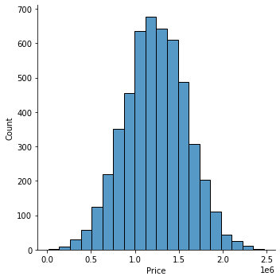

```python
sns.displot(data['Price'],bins=20,kde=False)
```

# EDA

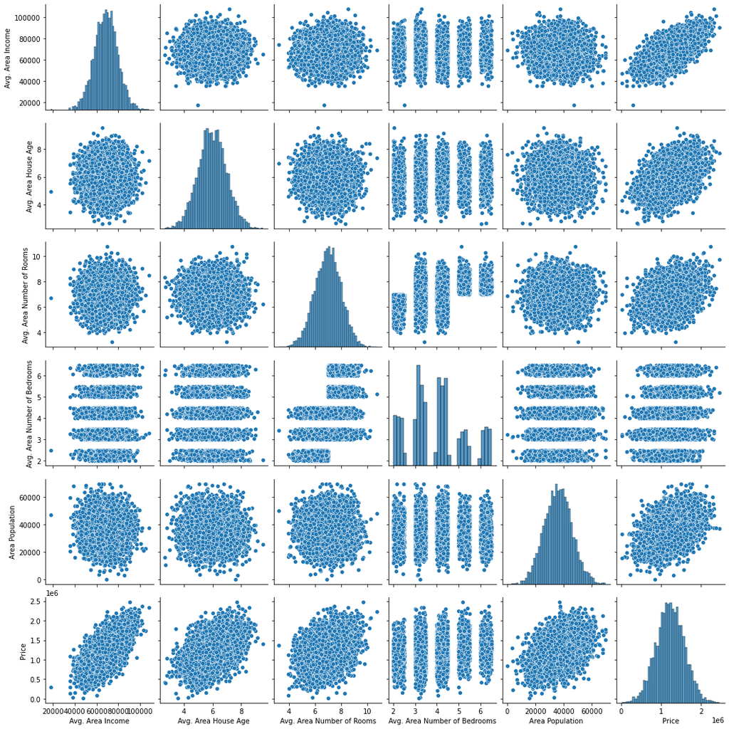

```python
sns.pairplot(data)
```

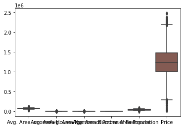

```python
sns.boxplot(data=data)
```

```python
r=data['Avg. Area Number of Rooms'].value_counts()
r
```

```
7.953781    1
6.695281    1
5.783416    1
7.830091    1
7.096020    1
           ..
7.780008    1
6.125859    1
6.499062    1
7.248288    1
6.740482    1
Name: Avg. Area Number of Rooms, Length: 5000, dtype: int64
```

```python
x=data.iloc[:,:5]
x
```

|  | Avg. Area Income | Avg. Area House Age | Avg. Area Number of Rooms | Avg. Area Number of Bedrooms | Area Population |
| --- | --- | --- | --- | --- | --- |
| 0 | 79545.45857 | 5.682861 | 7.009188 | 4.09 | 23086.80050 |
| 1 | 79248.64245 | 6.002900 | 6.730821 | 3.09 | 40173.07217 |
| 2 | 61287.06718 | 5.865890 | 8.512727 | 5.13 | 36882.15940 |
| 3 | 63345.24005 | 7.188236 | 5.586729 | 3.26 | 34310.24283 |
| 4 | 59982.19723 | 5.040555 | 7.839388 | 4.23 | 26354.10947 |
| ... | ... | ... | ... | ... | ... |
| 4995 | 60567.94414 | 7.830362 | 6.137356 | 3.46 | 22837.36103 |
| 4996 | 78491.27543 | 6.999135 | 6.576763 | 4.02 | 25616.11549 |
| 4997 | 63390.68689 | 7.250591 | 4.805081 | 2.13 | 33266.14549 |
| 4998 | 68001.33124 | 5.534388 | 7.130144 | 5.44 | 42625.62016 |
| 4999 | 65510.58180 | 5.992305 | 6.792336 | 4.07 | 46501.28380 |

5000 rows × 5 columns

```python
y=data.iloc[:,-2]
y
```

```
0       1.059034e+06
1       1.505891e+06
2       1.058988e+06
3       1.260617e+06
4       6.309435e+05
            ...
4995    1.060194e+06
4996    1.482618e+06
4997    1.030730e+06
4998    1.198657e+06
4999    1.298950e+06
Name: Price, Length: 5000, dtype: float64
```

```python
x.shape
```

```
(5000, 5)
```

# Train Test Split

```python
from sklearn.model_selection import train_test_split
x_train,x_test,y_train,y_test=train_test_split(x,y,test_size=0.4,random_state=101)
x_test.shape
```

```
(2000, 5)
```

```python
x_train.shape
```

```
(3000, 5)
```

```python
x_train.head()
```

|  | Avg. Area Income | Avg. Area House Age | Avg. Area Number of Rooms | Avg. Area Number of Bedrooms | Area Population |
| --- | --- | --- | --- | --- | --- |
| 1303 | 68091.17968 | 5.364208 | 7.502956 | 3.10 | 44557.37966 |
| 1051 | 75729.76555 | 5.580599 | 7.642973 | 4.21 | 29996.01845 |
| 4904 | 70885.42082 | 6.358747 | 7.250241 | 5.42 | 38627.30147 |
| 931 | 73386.40734 | 4.966360 | 7.915453 | 4.30 | 38413.49048 |
| 4976 | 75046.31379 | 5.351169 | 7.797825 | 5.23 | 34107.88862 |

# Creating and Training the Model

```python
from sklearn.linear_model import LinearRegression
lm=LinearRegression()
```

# جهت آموزش مدل از تابع fit

```python
lm.fit(x_train,y_train)
```

```
LinearRegression()
```

# Find Model Coeffelicients

```python
print(lm.intercept_)
```

```
-2640159.7968126033
```

```python
print(lm.coef_)
```

```
[2.15282755e+01 1.64883282e+05 1.22368678e+05 2.23380186e+03
 1.51504200e+01]
```

```python
predictions=lm.predict(x_test)
```

```python
predictions
```

```
array([1260960.70581765,  827588.75544668, 1742421.24257416, ...,
        372191.4061306 , 1365217.15136991, 1914519.54191678])
```

```python
predictions.shape
```

```
(2000,)
```

# مقایسه ایگرگ های تست و مقدار پیش بینی شده

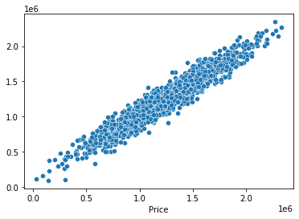

```python
sns.scatterplot(x=y_test,y=predictions)
```

# Residual Historam

```python
residual =y_test- predictions
residual
```

```
1718     -9272.089818
2511     45459.564153
345     -45443.579574
2521     89338.900507
54      -49929.566321
            ...
1776    -25522.673078
4269     31721.824513
1661   -220664.323531
2410    -21392.936370
2302     -8494.905917
Name: Price, Length: 2000, dtype: float64
```

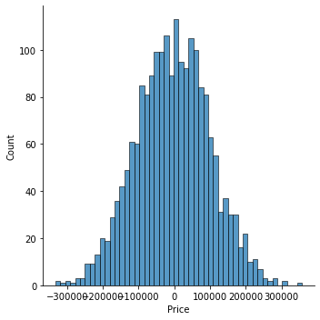

```python
sns.displot(residual,bins=50)
```

# محاسبه خطاها

```python
from sklearn import metrics
```

```python
print('MAE=',metrics.mean_absolute_error(y_test,predictions))
print('MSE=',metrics.mean_squared_error(y_test,predictions))
print('RMSE=',np.sqrt(metrics.mean_squared_error(y_test,predictions)))
```

```
MAE= 82288.22250721796
MSE= 10460958905.775496
RMSE= 102278.82921590125
```

فهم مسئله:

1. انگیزه اصلی چنین پروژهای چیست؟ هدف از انجام چنین پروژه هایی جمع آوری اطلاعات از عملکرد گذشته ودستیابی به آمار خاص و یا تحلیل و بررسی آنها برای تصمیم گری های بهینه برای رفع مشکل موجود و یا بررسی موانع پیشبرد فعالیت و همچنین ایجاد یک دید نسبت به رفتار های کنونی می باشد.
2. خروجی چنین پروژهای برای چه مواردی ممکن است کاربرد داشته باشد؟ • پزشکی • بازار دیجیتال • کشاورزی • ورزش • سینما و تلویزیون • آموزش • حوزه مالی • حمل و نقل • محیط زیست • ساخت و تولید • عملکرد شرکتها و فروشگاهها برای جذب مشتری
3. چه کسانی ممکن است به نتایج این پروژه علاقمند باشند؟ چرا؟ • تمامی افراد جامعه به نوعی می تونند علاقمند باشند. • هر کدام در حیطه فعالیت و علایق و کار خود و حتی بهبود کیفیت زندگی و تربیت و آموزش کودکان و رفع نیازهای روزمرگی زندگی خود .

   درک داده:
4. دادهها از کجا بدست آمده اند و چگونه جمع آوری شده اند؟ دادها در یک فایل csv جمع آوری شده بودن
5. هر یک از متغیرها چه چیزی را اندازه گیری میکنند؟ میانگین موارد موثر در قیمت خانه
6. آیا ابهامی در تعاریف داده ها وجود دارد؟ خیر
7. آیا ممکن است در اندازه گیری متغیرها و یا ثبت داده ها خطایی وجود داشته باشد؟ به همین دلیل وجود داده پرت، (Outlier Data) یا دورافتاده، که ممکن است براثر خطا اندازه‌ گیری بوجود آمده یا واقعا از اعضای استثنایی جامعه باشند، که همین شاخص‌ها ی اندازه گیری را به شدت تحت تاثیر قرار می‌دهند.
8. چه متغیرهای دیگری اگر وجود داشتند، میتوانست به حل مسئله کمک کند؟ • محل قرار گرفتن خانه در شهر • تجهیزات استفاده شده برای ساخت و یا اسکلت خانه • تعداد طبقات موجود در خانه • وجود تجهیزات سرمایشیو گرمایش
9. متغیرهای موجود از کدام نوعند(رستهای_عددی)؟ فقط آدرس از نوع غیر عددی بود و بقیه عددی بودن
10. خلاصه آماری متغیرهای موجود چیست؟ آماده سازی داده:
11. آیا نیاز به درآمیختن داده ها است؟ اقدامات و نتایج گزارش شود. خیر
12. آیا نیاز به پاکسازی داده است؟ اقدامات و نتایج گزارش شود. فقط آدرس که از نوع object بود
13. آیا نیاز به تبدیل داده است؟ اقدامات و نتایج گزارش شود. خیر
14. آیا نیاز به کاهش داده است؟ اقدامات و نتایج گزارش شود. خیر مدلسازی:
15. روی داده های آموزش ،الگوریتم رگرسیون ساخته شود .اقدامات و نتایج گزارش شود. ارزیابی:
16. مدلهای ارائه شده، روی دادههای آزمایش با استفاده از شاخصهای ارزیابی رگرسیون خطی 1 در یادگیری ماشین ارزیابی شوند .اقدامات و نتایج گزارش شود.
17. چه پیشنهاداتی دارید تا نتایج در محیط واقعی، آزمایش گردد؟ استقرار: حال اگر بخواهید چنین الگوریتمی را در مقیاس صنعتی توسعه دهید، به این فکر کنید با چه چالش هایی مواجه خواهید شد و برای آن چه راهکارهایی دارید. موارد زیر را گزارش کنید:
18. چالشهای توسعه الگوریتم را بررسی کنید.
19. چه راهکارهایی برای حل آن ها دارید؟
20. چه ملزوماتی برای ارائه آن راهکارها نیاز دارید؟ نتیجه گیری:
21. انجام این پروژه چه یادگیری برای شما داشت؟ آشنایی با کتابخانه های numpy, pandas, matplotlib , و رسم نمودار های مختلف و مشاهده و یادگیری کاربد عملی این کتابخانه ها
22. با چه چالشهایی مواجه شدید؟ چگونه آنها را حل کردید؟ به نظر من امکان دسته بندی داده ها وجود نداشت .